# Practice 1

Jorge Sanchez

1-13-23

## Baby names distribution

We will look into the distribution of baby names. This data set has almost 2 millions names from 1880 to 2017. It was provided by the Social Security Administration. It has the following variables:

- year: birth year
- sex: Female or Male
- name: baby name
- n: number of babies named “name” in that year with that sex

##### Data Wrangling

Read the data in R and called it **bbnames**:

```r
#Code here
# Load the data
bbnames = read.csv("https://pages.uwf.edu/acohen/teaching/datasets/bbnames.csv")
```

Find the proportions of people born in the same year and with same sex. That is prop = n divided by total number of applicants in that year and that sex. Create a new variable `prop` using `mutate` and added to **bbnames**:

```r
#Code here
install.packages('tidyverse', repos = "http://cran.us.r-project.org")
library(tidyverse)
library(dplyr)
# using the pipelines, i created a new column using the mutate function , then declare variable , finally create
# the year and sex group
bbnames %>% mutate(bbnames, prop=n/sum(n)) %>% group_by(year,sex)
```

```
## # A tibble: 1,924,665 × 5
## # Groups:   year, sex [276]
##     year sex   name          n       prop
##    <int> <chr> <chr>     <int>      <dbl>
##  1  1880 F     Mary       7065 0.0000203
##  2  1880 F     Anna       2604 0.00000748
##  3  1880 F     Emma       2003 0.00000575
##  4  1880 F     Elizabeth  1939 0.00000557
##  5  1880 F     Minnie     1746 0.00000502
##  6  1880 F     Margaret   1578 0.00000453
##  7  1880 F     Ida        1472 0.00000423
##  8  1880 F     Alice      1414 0.00000406
##  9  1880 F     Bertha     1320 0.00000379
## 10  1880 F     Sarah      1288 0.00000370
## # … with 1,924,655 more rows
```

Find the most popular, all time, name for each gender (hints: answer for females starts with **M** and males with **J**):

```r
#Code here
#filter the data to female Then summaries the unique names
topFemale = bbnames %>% filter(sex=="F") %>% summarise(names = unique(name))
#we display the string with the variable
cat("The popular female name is:", topFemale[1,])
```

```
## The popular female name is: Mary
```

```r
#Code here
#filter the data to male. Then summaries the unique names
topMale = bbnames %>% filter(sex=="M") %>% summarise(names = unique(name))
#we display the string with the variable
cat("The popular male name is:", topMale[1,])
```

```
## The popular male name is: John
```

Create a new data frame while creating a new variable `age` and filter by `age` - Pick a threshold that would keep only people who may still alive (you may use the age expectancy):

```r
#Code here

thresholdAge = 85
currentYear = 2023
bbnamesNew = mutate(bbnames, age= currentYear - year) %>% filter(age <= thresholdAge )
#new dataframe is created. Since there are more than 1576312, I am showing a counter and top of records
head(bbnamesNew)
```

```
##   year sex     name     n age
## 1 1938   F     Mary 56214  85
## 2 1938   F  Barbara 39277  85
## 3 1938   F Patricia 27555  85
## 4 1938   F    Betty 25503  85
## 5 1938   F  Shirley 23769  85
## 6 1938   F    Carol 19424  85
```

```r
nrow(bbnamesNew)
```

```
## [1] 1576312
```

##### Visualization

Use ggplot to plot the distribution of the name *John*. Use geom_bar, geom_line, and facet_wrap to separate females and males.

```r
#Code here
# data visualization
library(ggthemes)
library(ggrepel)
```

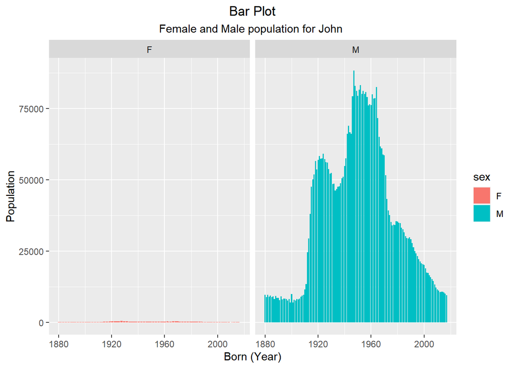

```r
myName <- "John"
names = bbnames %>% filter(name == myName)
myPlot = names %>% ggplot(aes(x=year, y = n))
myPlot  + geom_bar(stat = 'identity', aes(fill =sex)) +
          facet_wrap(~sex) +
          labs(title ="Bar Plot",
                 subtitle = "Female and Male population for John ",
                 x= "Born (Year)",
                 y ="Population")+
          theme(plot.title=element_text(hjust=0.5), #Centralize title and sub-title
          plot.subtitle=element_text(hjust=0.5))
```

Use ggplot to plot the distribution of the name of your choice. Use geom_bar, geom_line, and facet_wrap to separate females and males.

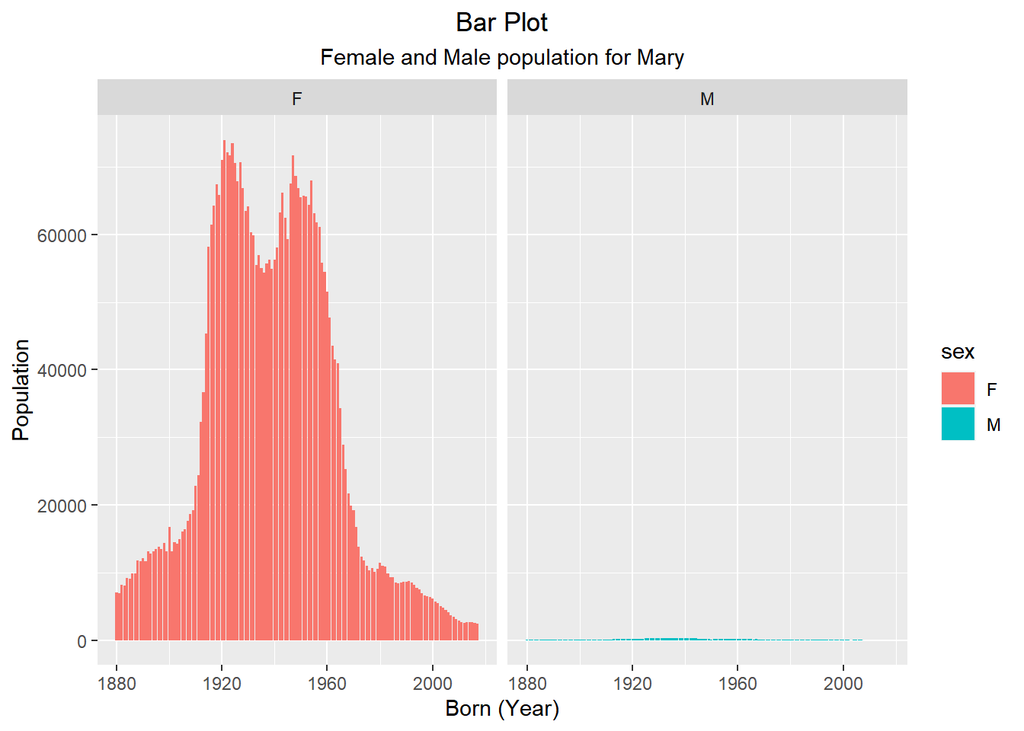

```r
#Code here
myName <- "Mary"
names = bbnames %>% filter(name == myName)
myPlot = names %>%ggplot(aes(x=year, y = n))
myPlot  + geom_bar(stat = 'identity', aes(fill =sex)) +
          facet_wrap(~sex) +
          labs(title ="Bar Plot",
                 subtitle = "Female and Male population for Mary",
                 x= "Born (Year)",
                 y ="Population")+
          theme(plot.title=element_text(hjust=0.5), #Centralize title and sub-title
          plot.subtitle=element_text(hjust=0.5))
```

## Diploma problem (hat-check)

10. You most likely heard about this problem before. Smith College is a residential women’s liberal arts college in Northampton, MA that is steeped in tradition. One such tradition is to give each student at graduation a diploma at random. At the end of the ceremony, a diploma circle is formed, and students pass the diplomas that they receive to the person next to them, and step out once they’ve received their diploma. What is the expected number of students who receive their diplomas in the initial disbursement?

The analytic solution (of the expect value) is easy to derive. Let $X_i$ is the event that $ith$ student receives their diploma then $E(X_i)=1/n$, for all i (the diplomas are uniformly distributed). n is the number of diplomas (students). Thus, if $Y$ is the sum of all the events $X_i$, then $E(Y)=1$. It is sometimes kind of surprising that the expected number of students receiving their diplomas in the initial disbursement does not depend on $n$. The variance can be more difficult to derive since $X_i$ are dependent.

We will solve the problem using simulations with R. Simulate the problem and find the expected value and the variance of the number of students who receive their diplomas in the initial giving.

```r
#Code here
myFunction = function(n,iter)
{
  stds = seq(1,n)
  dip_receive = numeric(iter)
  for (i in 1:iter) {
    diploma = sample(stds,n)
    dip_receive[i]=sum(stds==diploma)
  }
  exp_value = mean(dip_receive)
  variance = var(dip_receive)
  list(expected_value = exp_value, variance = variance)
}

n = 500
i = 7000
myFunction(n,i)
```

```
## $expected_value
## [1] 0.989
##
## $variance
## [1] 0.9835909
```